# Amostragem (MATD44)

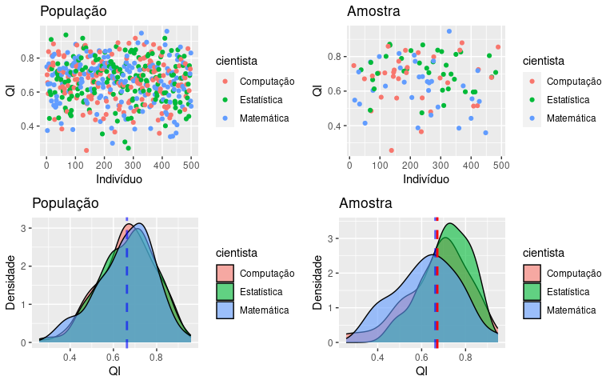

- **Professor:** Raydonal Ospina Martínez
- **Homepage do Curso:** https://raydonal.github.io/matd44/
- **Contato:** raydonalmartinez@ufba.br
- **Ementa do curso:** MATD44 Teoria estatística da amostragem. Critérios para a elaboração de um delineamento amostral. Amostragem aleatória simples. Amostragem aleatória estratificada. Amostragem sistemática. Noções de Amostragem por conglomerados.
- **Local e horário da disciplina:** As aulas serão ministradas às terças e quintas feiras das 8:50 às 10:40 horas (TURMA T01) na sala 215 do PAF I (PAF - Pavilhão de Aulas da Federação I - Av. Barão de Geremoabo - s/n - Ondina - Campus de Ondina).
- **Atenção aos estudantes:** Reunião virtual via google-meet ou reunião presencial com prévio agendamento. O local de atendimento presencial será em alguma sala disponível no Departamento de Estatística da UFBA.
- *Nota: O atendimento somente será realizado com agendamento prévio. Caro aluno, eu sou uma pessoa bastante ocupada e meu tempo, assim como o seu, é muito valioso. Use o tempo que você gastar comigo de forma eficiente. De preferência já traga anotações e perguntas já elaboradas. Seja pontual. Sempre.*
- **Inicio do curso:** 25 de março de 2025.
- **Pré-requisitos:** MATD42 - Inferência A. A disciplina também requer conhecimentos sólidos de algebra
- **Propósitos da disciplina:** Ajuda a compreender como selecionar amostras representativas de populações maiores. Ensina a coletar e analisar dados de pesquisa usando métodos de amostragem, úteis em pesquisas e estudos de mercado. Capacita a escolher métodos de amostragem apropriados para diferentes problemas. Permite estimar parâmetros populacionais a partir de dados de amostra, calcular intervalos de confiança e realizar testes de hipóteses. Prepara para carreiras em pesquisa, análise de dados e estatística aplicada. Ensina sobre erros e vieses na seleção de amostras e como evitá-los.
- **Objetivos da disciplina:** Neste curso, discutiremos métodos que facilitarão o planejamento, coleta e avaliação de dados provenientes de pesquisas amostrais. Após a introdução dos conceitos básicos de amostragem concentraremos nossa atenção na amostragem probabilística de populações finitas e no cálculo da distribuição amostral dos estimadores da amostra. Em seguida, abordaremos diferentes tipos de designs de amostragem, tais como: amostragem aleatória simples, amostragem estratificada e amostragem por conglomerados.

A avaliação tem como objetivo ajudar ao aluno a progredir nas suas aprendizagens e serve também para estabelecer os resultado dos conhecimentos e das competências adquiridas nos diferentes momentos do período acadêmico. A avaliação também contribui para a qualidade do sistema de ensino. Desta forma, os critérios de avaliação para este curso são:

| Avaliação | Porcentagem | Data da Prova |
| --- | --- | --- |
| Prova 1 | 35% | A definir |
| Prova 2 | 35% | A definir |
| Desafios | 30% | A definir |

A avaliação será constituída pela nota das atividades (que podem consistir em provas, listas de exercicios e/ou projetos a depender do desempenho e participação da turma). O grau atribuído ao aluno no final do curso será o da sua média global ponderada (média aritmética ponderada) entre as notas, i.e.,

### M = (0.35 * Prova 1)+(0.35 * Prova 2)+(0.3 * Desafios).

- **Nota:** Não haverá escalonamento de notas.

# Programa da disciplina (Tentativo)

| Semana | Tópicos | Atividade (geral) |
| --- | --- | --- |
| **1-3** | **Introdução à Amostragem** | - Introdução e conceitos básicos |
|  |  | - Levantamentos por amostragem vs censitários |
|  |  | - Unidades de análise, parâmetros e populações |
|  |  | - Tipos de levantamento por amostragem |
|  |  | - Tipos de amostras probabilísticas |
|  |  | - Erro amostral vs não amostral |
|  |  | - Ideias básicas sobre planejamento amostral |
|  |  | - Parâmetros, estimadores e erro quadrático médio |
| **4-5** | **Amostragem Aleatória Simples (AAS)** | - AAS com e sem reposição |
|  |  | - Estimadores da média, total e proporção populacional |
|  |  | - Intervalos de confiança |
|  |  | - Tamanho de amostra para precisão pré-fixada |
| **5-6** | **Amostragem Sistemática (AS)** | - Descrição do plano amostral AS |
|  |  | - Seleção de uma amostra sistemática |
| **6** | **Atividade 1** | - Atividade avaliativa |
| **7-8** | **Amostragem Aleatória Estratificada (AE)** | - AE: definições e notações |
|  |  | - Estimadores da média, total e proporção populacional |
|  |  | - Alocação da amostra e comparação com AAS |
|  |  | - Intervalos de confiança |
| **9** | **Estudo dirigido** | - Prática no `R`. Uso do pacote `survey` [Rmarkdow] |
| **10-13** | **Amostragem por Conglomerados** | - Definição de conglomerado |
|  |  | - Eficiência da amostragem por conglomerados |
|  |  | - Amostragem por conglomerados em uma etapa |
|  |  | - Comparação entre conglomerados de tamanhos diferentes |
|  |  | - Comparação AS com amostragem por conglomerado |
|  |  | - Estimação da média e variância da média amostral |
| **14** | **Atividade 2** | - Atividade avaliativa |
| **15** | **Estudo de caso** | - Estudo de caso de pesquisa em amostragem e tecnologia |
| **16** | **Estudo de caso** | - Avaliação dos tópicos abordados até o momento |
| **16** | **Atividade 3** | - Atividade avaliativa |

#### Referências bibliográficas (Principal)

1. [TILLÉ, Yves.]. **Sampling and estimation from finite populations.** John Wiley & Sons, 2020. (Livro principal I)
2. [Särndal, Carl-Erik, Bengt Swensson, and Jan Wretman.] **Model assisted survey sampling.** Springer Science & Business Media, 2003. (Livro principal II)
3. [Bolfarine, H. e Bussab, W. O.]. **Elementos de Amostragem**. Editora Edgard Blücher, 2005. (Livro principal III)
4. Pedro Luis do Nascimento Silva, Zélia Magalhães Bianchini e Antonio José Ribeiro Dias. **Amostragem: Teoria e Prática Usando R**. Disponível [aqui](https://amostragemcomr.github.io/livro/), 2020.
5. [MORETTIN, Pedro A.; SINGER, Julio M.] **Introdução à Ciência de Dados Fundamentos e Aplicações**. Versão parcial preliminar agosto 2019. Disponível [aqui](https://www.ime.usp.br/~jmsinger/MAE5755/cdados2019ago06.pdf), 2019.
6. [LEWIS, Taylor]. **Complex survey data analysis with SAS**. CRC Press, 2016.
7. [TILLÉ, Yves]. **Sampling algorithms**. Springer New York, 2006.
8. [Bakerman, Jordan]. **SAS ® Programming for R Users**. SAS Institute Inc., SAS, 2019.
9. [Lohr, Sharon]. **Sampling: design and analysis**. Chapman and Hall/CRC, 2021.

#### Referências bibliográficas

- Cochran, William. *Sampling Techniques.* New York, NY: Wiley, 1977.
- Fink, A. *How to sample in surveys.* Thousand Oaks, CA: SAGE Publications, 1995.
- Groves, Robert M. *Survey Errors and Survey Costs* (Wiley Series in Survey Methodology). Chichester, England: John Wiley and Sons, Ltd, 2004.
- Henry, G. T. *Practical sampling.* Thousand Oaks, CA: Sage Publications, 1990.
- Kalton, G. *An Introduction to Survey Sampling.* SAGE Publications: Thousand Oaks, CA, 1983.
- Kish, Leslie. *Survey Sampling.* New York, NY: Wiley-Interscience, New Ed edition January 20, 1995.
- Lyberg, L., and Kasprzyk, D. *Survey Measurement and Process Quality.* New York, NY: Wiley, 1997.

#### Software (Interessados em implementar seus conhecimentos)

1. [An Introduction to R](http://cran.r-project.org)
2. [SAS - Acadêmico](https://www.sas.com/pt_br/learn/academic-programs/software.html)
3. Rstudio
4. TeXnicCenter
5. [Python](http://www.python.org/)
6. [Julia](https://julialang.org/)

## Para refletir

##### Sobrea as aulas

*São reuniões cientificas e profissionais onde são discutidos temas de relevância para a formação pessoal, social e profissional. Portanto é esperado que o aluno chegue sem atraso, não entre na sala abruptamente, não sai da sala durante a discussão, respeite as intervenções do professor e/ou colega(s), não fume (Lei Federal), não use o celular (caso precisar pode se retirar da sala) e não promova a destruição de bens públicos, entre outros.*

##### Sobre honestidade acadêmica

*Honestidade e confiança são importantes para todos nós como indivíduos. Neste sentido, os membros da comunidade acadêmica tanto como professores e alunos têm a responsabilidade de manter e promover os princípios da verdade e honestidade acadêmica. Assim, a honestidade acadêmica pressupõe que todos os trabalhos, provas e testes sejam frutos do trabalho individual do aluno salvo os casos onde o professor tenha dado permissão expressa e instruções para a realização de atividades em grupo.*

##### Sobre profissionalismo

*Aluno, você já não é mais criança ou adolescente, mas adulto. Durante seu tempo na universidade, você formará quem você será pelas próximas décadas. O mercado de trabalho quer apenas os melhores e os mais profissionais. Haja desde já como o profissional que você deseja ser. (Fonte: Política do Curso e Etiqueta em Sala de Aula, Professor Dr. Renato J. Cintra).*

##### Sobre tratamento pessoal

*Lembrem que nós somos respeitados e tratados da mesma forma em que tratamos as demais pessoas. Ao se dirigir a professores e/ou colegas, faça-o respeitosamente.*

##### Sobre o aluno

*Finalmente quero lembrá-lo que você constrói seu conhecimento e desenvolve sua capacidade de aprender e criar. Seu instrutor está aqui para orientá-lo. Trabalhe, pesquise, seja crítico construtivo, crie, se dedique, se esforce e não desista, se pensar em desistir se esforce mais. Não se preocupe e melhor se ocupe. Você está aqui porque tem condições de vencer.*

### Material de apoio

O material de apoio será distribuído ao longo do curso. Esse material pode incluir, livros, slides de aula, scripts para reprodução, artigos científicos, artigos dedivulgação, entre outros.

- Hansen, M. H., & Hurwitz, W. N. (1943). On the theory of sampling from finite populations. The Annals of Mathematical Statistics, 14(4), 333-362. [Artigo]
- Hansen, M. H., & Hurwitz, W. N. (1949). On the determination of optimum probabilities in sampling. The Annals of Mathematical Statistics, 426-432. [Artigo]
- Horvitz, D. G., & Thompson, D. J. (1952). A generalization of sampling without replacement from a finite universe. Journal of the American statistical Association, 47(260), 663-685. [Artigo]

### Listas

- Lista de exercícios I -

- Bolfarine & Bussab (2005), Exercícios: 1.1, 1.3, 1.6, 1.11, 1.13, 2.1, 2.2, 2.6
- Tillé (2020). Exercícios: 2.1, 2.2,2.3, 2.4
- Särndal (2003). Exercícios: 2.1, 2.2, 2.3, 2.5

- Lista de exercícios II -

- Tillé (2020). Exercícios: 4.1, 4.2, 4.3, 4.4, 4.5, 4.6, 4.8

- Lista de exercícios III -

- Tillé (2020). Exercícios: 7.1, 7.2, 7.3

### Provas

- [ Prova I ] - [Notas]
- [ Prova II ] - [Notas]

### Desafios

[ Desafios / Conceitos] - [Notas]

- [ Nota Final ]

###### Content Copyright © 2025 Raydonal Ospina Martínez. All Rights Reserved.